# Glassdoor US Job Market Data

Reza Dwi Utomo @utomoreza

23/01/2020

# 1 Introduction

## 1.1 Background

This article aims to meet the first LBB (Learn by Building) assignment from Algoritma, i.e. [Programming for Data Science](https://algorit.ma/course/programming-data-science/). In this article, you could expect to find the following sections:

- Introduction of the article can be found in Introduction
- More detailed explanation of the data is in Dataset
- How to prepare the data can be read in Preparation
- Steps to clean the data is in Data Cleansing
- Steps to transform the data is found in Data Transformation
- Discussion about answering the pre-defined questions is described in Analysis
- Conclusions of the article can be read in Conclusions

Here, I intend to employ data from Glassdoor regarding job market in the US. You can find the web page [here](https://www.glassdoor.com/research/job-market-report-historical/). Also, Glassdoor has the visualizations for the data as shown [here](https://www.glassdoor.com/research/job-market-report/).

I published this article on [GitHub Page](https://utomoreza.github.io/P4DS_LBB/) and [RPubs](https://rpubs.com/utomoreza/P4DS_LBB), but you can find the codes on [GitHub](https://github.com/utomoreza/P4DS_LBB). Feel free to use or clone it.

## 1.2 Research Questions

By arranging this article, I’m going to answer several questions as follows:

1. What is the job title paid the most in each area in every given year?
2. Which top 5 sectors do pay salary the most in Boston every year?
3. Is it true that a company with more than 5000 employees in San Francisco pays its employees’ salary higher than a startup (a company with employees equal or less than 200) in NYC? Show the data in every year!
4. What is the relationship between salary and job openings in the US?

# 2 Dataset

The data are compiled monthly by Glassdoor from 2016. Each monthly datum is in .xlsx extension file. The columns of each of it consist of:

- Metro

Some metropolitan areas in the US. The National value indicates data from national area.

- Dimension Type

Type of data we want, e.g. Quick Facts (facts about median salary and job openings), Industry (sectors of the jobs), and so on.

- Month

The time format of the data.

- Dimension

This is the derivative of Dimension Type column. All options here depend on Dimension Type.

- Measure

This column determines what method of measurement used.

- Value

Depending on Dimension Type and Dimension columns you chose, this Value column contains either median salary or number of job openings. The value with ‘$’ (dollar) sign indicates salary in USD.

- YoY

Year over year in percent. For more information about how to understand and calculate YoY, you can read this [article](https://www.sisense.com/blog/calculate-year-year-growth/) I found really helpful. However, in this article, I won’t highlight this YoY feature.

Below is a quick look of the data in spreadsheet application.

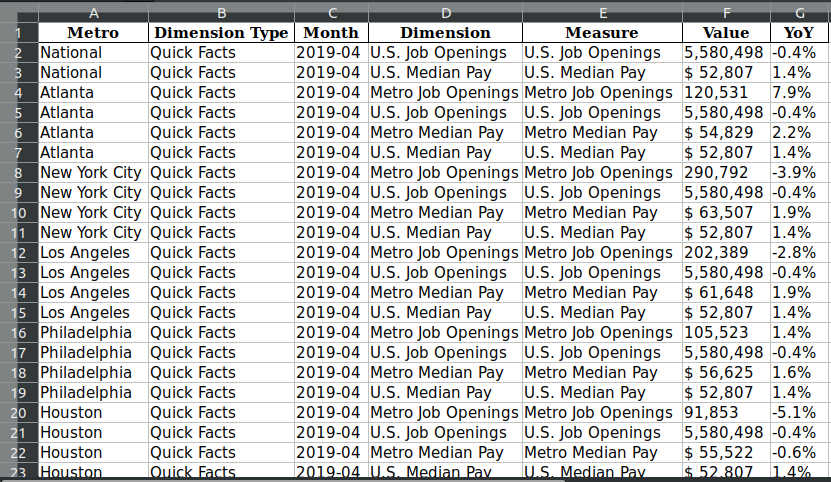

For more information regarding the data, you can read its methodology written exclusively by Glassdoor [here](https://www.glassdoor.com/research/app/uploads/sites/2/2019/04/Methodology-Glassdoor-Job-Market-Report-2-2.pdf).

# 3 Preparation

We have identified the data, so now we’re going to prepare the data. Although the total data started from 2016, in this article, I only use monthly data from 2018 and 2019; there are 24 .xlsx files. It will be time consuming and exhausting if we download each file one by one manually. Therefore, here we’re going to scrape the Glassdoor web page and download all necessary files automatically.

## 3.1 Load Necessary Packages

First thing first, we must load all libraries needed.

```r
library('readxl')
library('rvest')
library('lubridate')
library('zoo')
library('openxlsx')
library('tidyverse')
# library('kableExtra')
```

## 3.2 Download and Save the Data

In the code chunk below, we’re going to define a function called `get_xls_file_from_html()` used to scrape Glassdoor web page and download all .xlsx files there and save them in local directory with appropriate file names.

```r
get_xls_file_from_html <- function() {
     dataurl <- "https://www.glassdoor.com/research/job-market-report-historical/"
     page <- read_html(dataurl)

     excels1 <- grep("\\.xlsx", html_nodes(page, "a"), value = T)
     excels2 <- gsub(".*href=\"", "", excels1)
     excels <- gsub("xlsx.*", "xlsx", excels2)
     excels_path <- as.character(sapply(excels,
                                        FUN = substr,
                                        start = 64,
                                        stop = max(sapply(excels, nchar))))
     excels_path1_31 <- gsub(".*data-", "", excels_path[1:31])
     excels_path[32] <- "2017-05.xlsx"
     excels_path[33] <- "2017-04.xlsx"
     excels_path[34] <- "2017-03.xlsx"
     excels_path[35] <- "2017-02.xlsx"
     excels_path[36] <- "2017-01.xlsx"
     excels_path[37] <- "2016-12.xlsx"
     excels_path[38] <- "2016-11.xlsx"
     excels_path[39] <- "2016-10.xlsx"

     excels_path <- c(excels_path1_31, excels_path[32:39])

     destination <- paste("./datasets/", excels_path, sep = "")

     #file extraction
     mapply(function(x, y) download.file(x, y, mode="wb"), x = excels, y = destination)
}
```

The code chunk below is used to check whether we’ve had the xlsx files already in our local directory. If they do not exist, `get_xls_file_from_html()` will be excuted.

```r
load("filespath.RData")

checkIfFilesExist <- function(path){
  if (!file.exists(path)) {
    get_xls_file_from_html()
  }
}
```

## 3.3 Load the Data into RStudio

In order to load each monthly xlsx file into RStudio, we define a function `select_files_to_read()`.

```r
select_files_to_read <- function(month = "Dec", year = 2019) {
    load("filespath.RData")

    if (month == "Dec") {
        month_num = 1
    } else if (month == "Nov") {
        month_num = 2
    } else if (month == "Oct") {
        month_num = 3
    } else if (month == "Sep") {
        month_num = 4
    } else if (month == "Aug") {
        month_num = 5
    } else if (month == "Jul") {
        month_num = 6
    } else if (month == "Jun") {
        month_num = 7
    } else if (month == "May") {
        month_num = 8
    } else if (month == "Apr") {
        month_num = 9
    } else if (month == "Mar") {
        month_num = 10
    } else if (month == "Feb") {
        month_num = 11
    } else {
        month_num = 12
    }

    files <- list("2019" = filespath[1:12],
                  "2018" = filespath[13:24],
                  "2017" = filespath[25:36],
                  "2016" = filespath[37:39])

    if (year == 2016) {
        yearOrder <- 4
        if (month == "Dec" | month == "Nov" | month == "Oct") {
            xlsname <<- paste0(month, year)
            year_char <- as.character(year)
            tempfilename <<- as.data.frame(read_xlsx(files[[yearOrder]][month_num]))
        } else {
            stop("Year 2016 have Dec, Nov and Oct files only.")
        }
    } else {
        xlsname <<- paste0(month, year)
        if (year == 2019) {
            yearOrder <- 1
        } else if (year == 2018) {
            yearOrder <- 2
        } else {
            yearOrder <- 3
        }
        tempfilename <<- as.data.frame(read_xlsx(files[[yearOrder]][month_num]))
    }
}

dump("select_files_to_read", file = "select_files_to_read.R")
```

And now call the `select_files_to_read()` then insert it into another function `loadMultipleFiles()`. The latter works to iterate `select_files_to_read()` function in specified number of years fully.

```r
loadMultipleFiles <- function(nmonth = c("Dec"), nyear = c(2019)) {
     files_list1 <- list()
     year <- 1:length(nyear)
     month <- 1:length(nmonth)
     totalIterate <<- length(nmonth) * length(nyear)

     for (i in year) {
          if (length(year) == 1) {
               for (j in month) {
                    select_files_to_read(nmonth[j], nyear)
                    files_list1[[j]] <- tempfilename
                    names(files_list1)[j] <- xlsname
               }
               break
          }
          for (j in month) {

               select_files_to_read(nmonth[j], nyear[i])
               files_list1[[j]] <- tempfilename
               names(files_list1)[j] <- xlsname

          }

     }
     files_list <<- files_list1
}
```

After we’ve defined both functions above, now we’re going to use them by setting their arguments in order to load all monthly files in 2018 and 2019. The outputs of below chunk are dataframes of each monthly file.

```r
loadMultipleFiles(
  nmonth = c("Dec","Nov","Oct","Sep","Aug","Jul","Jun","May","Apr","Mar","Feb","Jan"),
  nyear = c(2018))

for (k in 1:totalIterate) {

     assign(names(files_list)[k], as.data.frame(files_list[[k]]))

}

loadMultipleFiles(
  nmonth = c("Dec","Nov","Oct","Sep","Aug","Jul","Jun","May","Apr","Mar","Feb","Jan"),
  nyear = c(2019))

for (k in 1:totalIterate) {

     assign(names(files_list)[k], as.data.frame(files_list[[k]]))

}
```

## 3.4 Combine months DFs into 1 DF (year)

After we’ve got all monthly dataframes, we should combine them in a single dataframe of year.

```r
year2019 <- rbind(Apr2019, Aug2019, Dec2019, Feb2019, Jan2019, Jul2019, Jun2019, Mar2019, May2019, Nov2019, Oct2019, Sep2019)

year2018 <- rbind(Apr2018, Aug2018, Dec2018, Feb2018, Jan2018, Jul2018, Jun2018, Mar2018, May2018, Nov2018, Oct2018, Sep2018)

year20182019 <- rbind(year2018, year2019)

## if you want, you can save the year dataframe as xls file in local directory
# write.xlsx(year2019, "./datasets/year2019.xlsx")
# write.xlsx(year2018, "./datasets/year2018.xlsx")
# write.xlsx(year20182019, "./datasets/year2018-2019.xlsx")

# for ease of use and saving more memory, we need to remove all unnecessary objects
temp_objects <- ls()
rm(list = temp_objects[!temp_objects %in% c("year20182019")])
rm(temp_objects)
```

Yeah! Finally, we’ve got our prepared file! Let’s move on to clean it.

# 4 Data Cleansing

First of all, since the file used is big enough, it is recommended to open it in any Spreadsheet application in advance to obtain and explore a quick insight regarding the data.

After viewing the file in Spreadsheet application more detail as shown in the picture in Introduction, firstly, we focus on `Dimension Type` column as it explains different information as follows:

1. Company Size

This value has the following Dimensions:

- <51 employees
- 51-200 employees
- 201-500 employees
- 501-1000 employees
- 1001-5000 employees
- +5000 employees
- Other: we should highlight this!
- Empty value: we should highlight this!

This column also has the following Measures:

- Job Openings (with format `<numbers>` only in `Value` column)
- Median Base Pay (with format either `<numbers>.0` or `<numbers>` in `Value` column)
2. Industry

This value has a number of list of sectors. I’m not going to write it down here. And, this value has the following Measures:

- Job Openings (with format `<numbers>` only in `Value` column)
- Median Base Pay (with format either `<numbers>.0` or `<numbers>` in `Value` column)
3. Job Title

This value has a number of list of job titles. I’m not going to write it down here. And, this value has one Measure only, i.e. Median Base Pay (with format either `$ <numbers>,<numbers>` or `$<numbers>,<numbers>` in `Value` column).

4. Quick Facts

This value’s Dimension and Measures are perfectly equal which are the followings:

- Job Openings (with format `<numbers>,<numbers>` in `Value` column)
- Labor Force Size (with format `<numbers>,<numbers>,<numbers>` in `Value` column)
- Metro Job Openings (with format `<numbers>,<numbers>` in `Value` column)
- Metro Median Pay (with format either `$ <numbers>,<numbers>` or `$<numbers>,<numbers>` in `Value` column)
- Total Employment (with format `<number>,<numbers>,<numbers>` in `Value` column)
- US Job Openings (with format `<number>,<numbers>,<numbers>` in `Value` column)
- US Median Pay (with format `$ <numbers>,<numbers>` in `Value` column)
- Unemployment Rate (with format `<number>.<number>%` in `Value` column)
5. Timeseries

This value’s Dimension and Measures are perfectly equal which are the followings:

- Job Openings (with format either `<numbers>.<numbers>` or `<numbers>` in `Value` column)
- Median Base Pay (with format either `<numbers>.<numbers>` or `<numbers>` in `Value` column)

Particulary for Labor Force Size, Total Employment, and Unemployment Rate in Quick Facts, I don’t need them as their data are too limited. I will remove those later in the next section.

After we saw the data in Excel-like app already, we’re going to back to R to manipulate the data. First, let’s see the data structure.

```r
str(year20182019)
```

```
## 'data.frame':    72455 obs. of  7 variables:
##  $ Metro         : chr  "National" "Atlanta" "Atlanta" "Atlanta" ...
##  $ Dimension Type: chr  "Quick Facts" "Quick Facts" "Quick Facts" "Quick Facts" ...
##  $ Month         : chr  "2018-04" "2018-04" "2018-04" "2018-04" ...
##  $ Dimension     : chr  "U.S. Median Pay" "Metro Median Pay" "U.S. Median Pay" "Job Openings" ...
##  $ Measure       : chr  "U.S. Median Pay" "Metro Median Pay" "U.S. Median Pay" "Job Openings" ...
##  $ Value         : chr  "$ 51,927" "$ 53,732" "$ 51,927" "118,496" ...
##  $ YoY           : chr  "1.2%" "1.9%" "1.2%" "16.5%" ...
```

Based on the information above, we need to change data type a number of columns. However, before we begin do that, for the sake of convenience, we need to fix two columns’ name: - “Dimension Type” to “Dimention_Type” - “Month” to “Date”

```r
colnames(year20182019) <- c("Metro", "Dimension_Type", "Date", "Dimension", "Measure", "Value", "YoY")
```

Then, referring to the data structure above, all columns’ data type are in character data type initially. By using our judgement, we’re sure the columns of `Date`, `Value`, and `YoY` should be in date, numeric, and numeric data type respectively. But, for the rest of columns, we have to make sure whether they should be left as they are or be changed to factor data type.

## 4.1 Drop NA Value

As a starter, let’s check whether NA exists.

```r
year20182019 %>% is.na() %>% colSums()
```

```
##          Metro Dimension_Type           Date      Dimension        Measure
##              0              0              0             88              0
##          Value            YoY
##            297          45671
```

We can see that NA exist in `Dimension`, `Value`, and `YoY` columns. Let’s see each of column with NA values.

```r
year20182019[is.na(year20182019$Dimension),]
```

|  | Metro | Dimension_Type | Date | Dimension | Measure | Value | YoY |
| --- | --- | --- | --- | --- | --- | --- | --- |
| 32772 | National | Company Size | 2019-08 | NA | Job Openings | 457139 | 0.04447197632030186 |
| 32779 | Atlanta | Company Size | 2019-08 | NA | Job Openings | 9964 | 0.2951421608448417 |
| 32786 | Boston | Company Size | 2019-08 | NA | Job Openings | 12902 | 0.3505966712027635 |
| 32793 | Chicago | Company Size | 2019-08 | NA | Job Openings | 14128 | -0.1743951612903226 |
| 32800 | Houston | Company Size | 2019-08 | NA | Job Openings | 7640 | -0.1804993161888928 |
| 32807 | Los Angeles | Company Size | 2019-08 | NA | Job Openings | 15262 | -0.09978765446662929 |
| 32814 | New York City | Company Size | 2019-08 | NA | Job Openings | 23692 | -0.08629965291168529 |
| 32821 | Philadelphia | Company Size | 2019-08 | NA | Job Openings | 7971 | 0.1361530786773091 |
| 32828 | San Francisco | Company Size | 2019-08 | NA | Job Openings | 9186 | 0.117046180038306 |
| 32835 | Seattle | Company Size | 2019-08 | NA | Job Openings | 6784 | 0.2083184894905594 |

[output cut: 78 more lines]

From the dataframe above, it can be seen that the 88 NAs occur on `Dimension_Type == "Company Size"` and `Measure == "Job Openings"` only.

```r
year20182019[is.na(year20182019$Value),]
```

|  | Metro | Dimension_Type | Date | Dimension | Measure | Value | YoY |
| --- | --- | --- | --- | --- | --- | --- | --- |
| 24562 | National | Timeseries | 2014-01-06 | Job Openings | Job Openings | NA | NA |
| 24563 | National | Timeseries | 2014-01-13 | Job Openings | Job Openings | NA | NA |
| 24564 | National | Timeseries | 2014-01-20 | Job Openings | Job Openings | NA | NA |
| 24838 | Atlanta | Timeseries | 2014-01-06 | Job Openings | Job Openings | NA | NA |
| 24839 | Atlanta | Timeseries | 2014-01-13 | Job Openings | Job Openings | NA | NA |
| 24840 | Atlanta | Timeseries | 2014-01-20 | Job Openings | Job Openings | NA | NA |
| 25114 | New York City | Timeseries | 2014-01-06 | Job Openings | Job Openings | NA | NA |
| 25115 | New York City | Timeseries | 2014-01-13 | Job Openings | Job Openings | NA | NA |
| 25116 | New York City | Timeseries | 2014-01-20 | Job Openings | Job Openings | NA | NA |
| 25390 | Los Angeles | Timeseries | 2014-01-06 | Job Openings | Job Openings | NA | NA |

[output cut: 287 more lines]

It can be seen from dataframe above that the 297 NA values in `Value` column only happen in `Dimension_Type == "Timeseries"`, `Dimension == "Job Openings`, and `Dimension == "Job Openings`.

```r
year20182019[is.na(year20182019$YoY),]
```

|  | Metro | Dimension_Type | Date | Dimension | Measure | Value | YoY |
| --- | --- | --- | --- | --- | --- | --- | --- |
| 956 | National | Company Size | 2018-04 | 1001-5000 | Median Base Pay | 51798.0 | NA |
| 957 | National | Company Size | 2018-04 | <51 | Median Base Pay | 46837.0 | NA |
| 958 | National | Company Size | 2018-04 | 201-500 | Median Base Pay | 49756.0 | NA |
| 959 | National | Company Size | 2018-04 | 5000+ | Median Base Pay | 52373.0 | NA |
| 960 | National | Company Size | 2018-04 | 501-1000 | Median Base Pay | 50500.0 | NA |
| 961 | National | Company Size | 2018-04 | 51-200 | Median Base Pay | 48812.0 | NA |
| 962 | New York City | Company Size | 2018-04 | 1001-5000 | Median Base Pay | 61299.0 | NA |
| 963 | New York City | Company Size | 2018-04 | <51 | Median Base Pay | 55429.0 | NA |
| 964 | New York City | Company Size | 2018-04 | 201-500 | Median Base Pay | 58883.0 | NA |
| 965 | New York City | Company Size | 2018-04 | 5000+ | Median Base Pay | 61980.0 | NA |

[output cut: 9990 more lines]

From dataframe above, it can be seen that there are lots of NAs in `YoY` column. However, since we’re not interested in YoY in this article, it’s not a problem if we completely drop this column. Then, we clear all NAs in the other two columns.

```r
DF <- year20182019[-c(length(year20182019))]
DF <- drop_na(DF)
head(DF)
```

|  | Metro | Dimension_Type | Date | Dimension | Measure | Value |
| --- | --- | --- | --- | --- | --- | --- |
| 1 | National | Quick Facts | 2018-04 | U.S. Median Pay | U.S. Median Pay | $ 51,927 |
| 2 | Atlanta | Quick Facts | 2018-04 | Metro Median Pay | Metro Median Pay | $ 53,732 |
| 3 | Atlanta | Quick Facts | 2018-04 | U.S. Median Pay | U.S. Median Pay | $ 51,927 |
| 4 | Atlanta | Quick Facts | 2018-04 | Job Openings | Job Openings | 118,496 |
| 5 | New York City | Quick Facts | 2018-04 | Metro Median Pay | Metro Median Pay | $ 61,590 |
| 6 | New York City | Quick Facts | 2018-04 | U.S. Median Pay | U.S. Median Pay | $ 51,927 |

```r
is.na(DF) %>% colSums()
```

```
##          Metro Dimension_Type           Date      Dimension        Measure
##              0              0              0              0              0
##          Value
##              0
```

In addition, as I pointed earlier, I won’t use `Dimension == "Labor Force Size"`, `Dimension == "Total Employment"`, and `Dimension == "Unemployment Rate"`. So, let’s drop them down.

```r
DF <- DF[DF$Dimension != "Labor Force Size" &
           DF$Dimension != "Total Employment" &
           DF$Dimension != "Unemployment Rate",]

head(DF)
```

|  | Metro | Dimension_Type | Date | Dimension | Measure | Value |
| --- | --- | --- | --- | --- | --- | --- |
| 1 | National | Quick Facts | 2018-04 | U.S. Median Pay | U.S. Median Pay | $ 51,927 |
| 2 | Atlanta | Quick Facts | 2018-04 | Metro Median Pay | Metro Median Pay | $ 53,732 |
| 3 | Atlanta | Quick Facts | 2018-04 | U.S. Median Pay | U.S. Median Pay | $ 51,927 |
| 4 | Atlanta | Quick Facts | 2018-04 | Job Openings | Job Openings | 118,496 |
| 5 | New York City | Quick Facts | 2018-04 | Metro Median Pay | Metro Median Pay | $ 61,590 |
| 6 | New York City | Quick Facts | 2018-04 | U.S. Median Pay | U.S. Median Pay | $ 51,927 |

```r
is.na(DF) %>% colSums()
```

```
##          Metro Dimension_Type           Date      Dimension        Measure
##              0              0              0              0              0
##          Value
##              0
```

Excellent! All data clean! Then, now let’s move on to set the data type of each column.

## 4.2 Change Data Type

- `Metro` column

```r
unique(DF$Metro)
```

```
##  [1] "National"      "Atlanta"       "New York City" "Los Angeles"
##  [5] "Philadelphia"  "Houston"       "Seattle"       "San Francisco"
##  [9] "Chicago"       "Boston"        "Washington DC" "U.S."
## [13] "New-York-City" "Los-Angeles"   "San-Francisco" "Washington-DC"
```

For `Metro` column, there are 16 unique observations only. However, if you see them more closely, there are some areas with the same meaning but in slight different typing. Therefore, it will be more easier to handle if we tackle with this problem and change this column to factor data type.

```r
DF$Metro <- as.factor(sapply(as.character(DF$Metro), switch,
                           "National" = "National",
                           "Atlanta" = "Atlanta",
                           "New York City" = "New York City",
                           "Los Angeles" = "Los Angeles",
                           "Philadelphia" = "Philadelphia",
                           "Houston" = "Houston",
                           "Seattle" = "Seattle",
                           "San Francisco" = "San Francisco",
                           "Chicago" = "Chicago",
                           "Boston" = "Boston",
                           "Washington DC" = "Washington DC",
                           "U.S." = "National",
                           "New-York-City" = "New York City",
                           "Los-Angeles" = "Los Angeles",
                           "San-Francisco" = "San Francisco",
                           "Washington-DC" = "Washington DC"))

levels(DF$Metro)
```

```
##  [1] "Atlanta"       "Boston"        "Chicago"       "Houston"
##  [5] "Los Angeles"   "National"      "New York City" "Philadelphia"
##  [9] "San Francisco" "Seattle"       "Washington DC"
```

Great! We’ve solved the problem and changed the data type of `Metro` column.

- `Dimension_Type` column

```r
unique(DF$Dimension_Type)
```

```
## [1] "Quick Facts"  "Job Title"    "Company Size" "Industry"     "Timeseries"
```

For `Dimension_Type` column, there are 5 unique observations only so that no wonder if we need to change its data type to factor immediately.

```r
DF$Dimension_Type <- as.factor(DF$Dimension_Type)
```

- `Dimension` column

```r
unique(DF$Dimension)
```

```
##   [1] "U.S. Median Pay"                  "Metro Median Pay"
##   [3] "Job Openings"                     "Software Engineer"
##   [5] "Programmer Analyst"               "Consultant"
##   [7] "Project Manager"                  "Store Manager"
##   [9] "Business Analyst"                 "Cashier"
##  [11] "Financial Analyst"                "Administrative Assistant"
##  [13] "Accountant"                       "Sales Representative"
##  [15] "Professor"                        "Registered Nurse"
##  [17] "Marketing Manager"                "Operations Manager"
##  [19] "Product Manager"                  "Sales Manager"
##  [21] "Teacher"                          "Bank Teller"
##  [23] "Customer Service Manager"         "Physical Therapist"
##  [25] "Mechanical Engineer"              "Recruiter"
##  [27] "Design Engineer"                  "Pharmacy Technician"
##  [29] "Graphic Designer"                 "Web Developer"
```

[output cut: 53 more lines]

```r
length(unique(DF$Dimension))
```

```
## [1] 135
```

For `Dimension` column, there 135 unique observations. That’s a big number! So, we just leave its data type as it is.

- `Measure` column

```r
unique(DF$Measure)
```

```
## [1] "U.S. Median Pay"    "Metro Median Pay"   "Job Openings"
## [4] "Median Base Pay"    "U.S. Job Openings"  "Metro Job Openings"
```

For `Measure` column, there are 6 unique observations only. So, let’s change its data type to factor.

```r
DF$Measure <- as.factor(DF$Measure)
```

- `Date` column

While we’re sure `Date` column should be in date data type, we still need to arrange its data type. Before we begin, let’s take a quick look at the head and tail of such column.

```r
head(DF$Date)
```

```
## [1] "2018-04" "2018-04" "2018-04" "2018-04" "2018-04" "2018-04"
```

```r
tail(DF$Date)
```

```
## [1] "2019-09" "2019-09" "2019-09" "2019-09" "2019-09" "2019-09"
```

We saw that the format of the column is in year-month, without date. However, since the total number of rows of the data is 50015, we are not sure yet whether all observations of such column are written in the same format. What if there are some row written in year-month-date or even other format?

To answer this, let’s see the column deeper by using `unique()`.

```r
as.data.frame(unique(DF$Date))
```

| unique(DF$Date) |
| --- |
| 2018-04 |
| 2018-03 |
| 2018-02 |
| 2018-01 |
| 2017-12 |
| 2017-11 |
| 2017-10 |
| 2017-09 |
| 2017-08 |
| 2017-07 |

[output cut: 371 more lines]

Bingo! As I told you, there are some with year-month-date format. Therefore, we’ve got two formats in one column. And since this is annoying, we have to unify all observations to one format only. So, we have two format options: year-month or year-month-date.

If we were to choose the first option, we will lose other observations’ date information so that this option is not affordable. Then, if we were to choose another option, the consequence is that we have to coerce the year-month format oservations to year-month-date format. Simply, we could insert ‘dummy’ date, i.e. 01, at the end of each year-month observation. Therefore, I think it will be more comfortable if we select the second choice.

```r
isString7Chars <- function(input) {
     if (nchar(input) == 7) {
          output <- paste0(input, '-01')
     } else {
          output <- input
     }
}

DF$Date <- as.character(sapply(DF$Date, isString7Chars)) %>%
     ymd()
```

- `Value` column

We stated earlier that `Value` should be in numeric data type. Furthermore, it was mentioned in the beginning of Data Cleansing that there is a number of `Value` column formats (after removing some rows). They are as follows:

- `<numbers>`
- `<numbers>.0`
- `<numbers>,<numbers>`
- `$ <numbers>,<numbers>`
- `$<numbers>,<numbers>`
- `<number>,<numbers>,<numbers>`

Before we jump to data type change, we have to handle those formats to make them in uniform format. We can use the following codes.

```r
DropDollar <- function(input){
     output <- gsub("\\$", "", input)
     output <- gsub(" ", "", output)
     output <- gsub(",", "", output)
     return(output)
}

DF$Value <- round(as.numeric(sapply(DF$Value, DropDollar)))
```

Well done! We have adjusted all columns’ format. So, now let’s check it the data out to convince ourself that we did well.

```r
head(DF)
```

|  | Metro | Dimension_Type | Date | Dimension | Measure | Value |
| --- | --- | --- | --- | --- | --- | --- |
| 1 | National | Quick Facts | 2018-04-01 | U.S. Median Pay | U.S. Median Pay | 51927 |
| 2 | Atlanta | Quick Facts | 2018-04-01 | Metro Median Pay | Metro Median Pay | 53732 |
| 3 | Atlanta | Quick Facts | 2018-04-01 | U.S. Median Pay | U.S. Median Pay | 51927 |
| 4 | Atlanta | Quick Facts | 2018-04-01 | Job Openings | Job Openings | 118496 |
| 5 | New York City | Quick Facts | 2018-04-01 | Metro Median Pay | Metro Median Pay | 61590 |
| 6 | New York City | Quick Facts | 2018-04-01 | U.S. Median Pay | U.S. Median Pay | 51927 |

Alright. All columns have been in appropriate data type. For the next step, let’s move on to the next section below.

# 5 Data Transformation

As our data is too complicated to infer directly from one table, it will be more convenient if we split it into several subtables: salary for each job title, salary for each sector, salary for each company size, job openings for each sector, job openings for each company size, quick facts, and time series.

## 5.1 Create a Table “Salary for each job title”

This subtable consists of median salary for each job title in a given specific metro area and on a specific date. To create it, we extract some columns from our main data. We’re only interested in `Dimension_Type` of `"Job Title"`.

```r
Salary_Jobs <- DF %>%
     filter(Dimension_Type == "Job Title") %>%
     select(Metro, Date, Dimension, Value)
colnames(Salary_Jobs) <- c("Area","Date","Job_Title", "Salary")
head(Salary_Jobs)
```

|  | Area | Date | Job_Title | Salary |
| --- | --- | --- | --- | --- |
| 1 | National | 2018-04-01 | Software Engineer | 86403 |
| 2 | National | 2018-04-01 | Programmer Analyst | 69239 |
| 3 | National | 2018-04-01 | Consultant | 72120 |
| 4 | National | 2018-04-01 | Project Manager | 73575 |
| 5 | National | 2018-04-01 | Store Manager | 48974 |
| 6 | National | 2018-04-01 | Business Analyst | 65094 |

Great! We’ve got what we desired. As we have new table, it’s gonna be better if we assign `Job Title` column data type to factor because job titles are just an iteration for each area and date.

```r
Salary_Jobs$Job_Title <- as.factor(Salary_Jobs$Job_Title)
levels(Salary_Jobs$Job_Title)
```

```
##  [1] "Accountant"                      "Administrative Assistant"
##  [3] "Attorney"                        "Bank Teller"
##  [5] "Barista"                         "Bartender"
##  [7] "Business Analyst"                "Business Development Manager"
##  [9] "Buyer"                           "Cashier"
## [11] "Certified Nursing Assistant"     "Civil Engineer"
## [13] "Claims Adjuster"                 "Communications Manager"
## [15] "Construction Laborer"            "Consultant"
## [17] "Customer Service Manager"        "Customer Service Representative"
## [19] "Data Analyst"                    "Data Scientist"
## [21] "Delivery Driver"                 "Design Engineer"
## [23] "Electrical Engineer"             "Emergency Medical Technician"
## [25] "Field Engineer"                  "Financial Advisor"
## [27] "Financial Analyst"               "Graphic Designer"
## [29] "Human Resources Manager"         "Insurance Agent"
```

[output cut: 28 more lines]

## 5.2 Create a Table “Salary for each sector”

This subtable consists of median salary for each sector in a given specific metro area and on a specific date. To create it, we extract some columns from our main data. We’re only interested in `Dimension_Type` of `"Industry"` and `Measure` of `"Median Base Pay"`.

```r
Salary_Sectors <- DF %>%
     filter(Dimension_Type == "Industry" & Measure == "Median Base Pay") %>%
     select(Metro, Date, Dimension, Value)
colnames(Salary_Sectors) <- c("Area","Date","Sector", "Salary")
head(Salary_Sectors)
```

|  | Area | Date | Sector | Salary |
| --- | --- | --- | --- | --- |
| 1 | National | 2018-04-01 | Accounting & Legal | 51323 |
| 2 | National | 2018-04-01 | Aerospace & Defense | 53458 |
| 3 | National | 2018-04-01 | Architecture & Civil Engineering | 52446 |
| 4 | National | 2018-04-01 | Arts & Entertainment | 46256 |
| 5 | National | 2018-04-01 | Automotive | 46801 |
| 6 | National | 2018-04-01 | Banking & Financial Services | 51139 |

As we have new table, it’s gonna be better if we assign `Sector` column data type to factor because sectors are just an iteration for each area and date.

```r
Salary_Sectors$Sector <- as.factor(Salary_Sectors$Sector)
levels(Salary_Sectors$Sector)
```

```
##  [1] "Accounting & Legal"               "Aerospace & Defense"
##  [3] "Architecture & Civil Engineering" "Arts & Entertainment"
##  [5] "Automotive"                       "Banking & Financial Services"
##  [7] "Beauty & Fitness"                 "Biotech & Pharmaceuticals"
##  [9] "Business Services"                "Computer Software & Hardware"
## [11] "Construction"                     "Consulting"
## [13] "Consumer Electronics"             "Consumer Services"
## [15] "Education & Schools"              "Energy & Utilities"
## [17] "Facilities"                       "Farming & Agriculture"
## [19] "Government"                       "Health Care & Hospitals"
## [21] "Information Technology"           "Insurance"
## [23] "Internet & Tech"                  "Manufacturing"
## [25] "Marketing & Advertising"          "Media & Publishing"
## [27] "Nonprofit"                        "Private Security"
## [29] "Real Estate"                      "Recruiting & Staffing"
## [31] "Restaurants & Bars"               "Retail"
## [33] "Supermarkets"                     "Telecommunications"
## [35] "Transportation & Logistics"       "Travel & Tourism"
## [37] "Wholesale"
```

## 5.3 Create a Table “Salary for each company size”

This subtable consists of median salary for each company size in a given specific metro area and on a specific date. To create it, we extract some columns from our main data. We’re only interested in `Dimension_Type` of `"Company Size"` and `Measure` of `"Median Base Pay"`.

```r
Salary_CompanySize <- DF %>%
     filter(Dimension_Type == "Company Size" & Measure == "Median Base Pay") %>%
     select(Metro, Date, Dimension, Value)
colnames(Salary_CompanySize) <- c("Area","Date","Company_Size", "Salary")
head(Salary_CompanySize)
```

|  | Area | Date | Company_Size | Salary |
| --- | --- | --- | --- | --- |
| 1 | National | 2018-04-01 | 1001-5000 | 51798 |
| 2 | National | 2018-04-01 | <51 | 46837 |
| 3 | National | 2018-04-01 | 201-500 | 49756 |
| 4 | National | 2018-04-01 | 5000+ | 52373 |
| 5 | National | 2018-04-01 | 501-1000 | 50500 |
| 6 | National | 2018-04-01 | 51-200 | 48812 |

Next, we’re going to assign `Company_Size` column data type to factor because company sizes are just an iteration for each area and date.

```r
Salary_CompanySize$Company_Size <- as.factor(Salary_CompanySize$Company_Size)
levels(Salary_CompanySize$Company_Size)
```

```
## [1] "<51"       "1001-5000" "201-500"   "5000+"     "501-1000"  "51-200"
```

## 5.4 Create a Table “Job openings for each sector”

This subtable consists of number of job openings and its YoY for each sector in a given specific metro area and on a specific date. To create it, we extract some columns from our main data. We’re only interested in `Dimension_Type` of `"Industry"` and `Measure` of `"Job Openings"`.

```r
JobOpening_Sectors <- DF %>%
     filter(Dimension_Type == "Industry" & Measure == "Job Openings") %>%
     select(Metro, Date, Dimension, Value)
colnames(JobOpening_Sectors) <- c("Area","Date","Sector", "Openings")
head(JobOpening_Sectors)
```

|  | Area | Date | Sector | Openings |
| --- | --- | --- | --- | --- |
| 1 | National | 2019-04-01 | Accounting & Legal | 51696 |
| 2 | National | 2019-04-01 | Aerospace & Defense | 78756 |
| 3 | National | 2019-04-01 | Architecture & Civil Engineering | 37760 |
| 4 | National | 2019-04-01 | Arts & Entertainment | 52260 |
| 5 | National | 2019-04-01 | Automotive | 86948 |
| 6 | National | 2019-04-01 | Banking & Financial Services | 127170 |

And now, we assign `Sector` column data type to factor because sectors are just an iteration for each area and date.

```r
JobOpening_Sectors$Sector <- as.factor(JobOpening_Sectors$Sector)
levels(JobOpening_Sectors$Sector)
```

```
##  [1] "Accounting & Legal"               "Aerospace & Defense"
##  [3] "Architecture & Civil Engineering" "Arts & Entertainment"
##  [5] "Automotive"                       "Banking & Financial Services"
##  [7] "Beauty & Fitness"                 "Biotech & Pharmaceuticals"
##  [9] "Business Services"                "Computer Software & Hardware"
## [11] "Construction"                     "Consulting"
## [13] "Consumer Electronics"             "Consumer Services"
## [15] "Education & Schools"              "Energy & Utilities"
## [17] "Facilities"                       "Farming & Agriculture"
## [19] "Government"                       "Health Care & Hospitals"
## [21] "Information Technology"           "Insurance"
## [23] "Internet & Tech"                  "Manufacturing"
## [25] "Marketing & Advertising"          "Media & Publishing"
## [27] "Nonprofit"                        "Other"
## [29] "Private Security"                 "Real Estate"
## [31] "Recruiting & Staffing"            "Restaurants & Bars"
## [33] "Retail"                           "Supermarkets"
## [35] "Telecommunications"               "Transportation & Logistics"
## [37] "Travel & Tourism"                 "Wholesale"
```

## 5.5 Create a Table “Job openings for each company size”

This subtable consists of number of job openings and its YoY for each company size in a given specific metro area and on a specific date. To create it, we extract some columns from our main data. We’re only interested in `Dimension_Type` of `"Company Size"` and `Measure` of `"Job Openings"`.

```r
JobOpening_CompanySize <- DF %>%
     filter(Dimension_Type == "Company Size" & Measure == "Job Openings") %>%
     select(Metro, Date, Dimension, Value)
colnames(JobOpening_CompanySize) <- c("Area","Date","Company_Size", "Openings")
head(JobOpening_CompanySize)
```

|  | Area | Date | Company_Size | Openings |
| --- | --- | --- | --- | --- |
| 1 | National | 2019-04-01 | 1001-5000 | 971870 |
| 2 | National | 2019-04-01 | 201-500 | 445838 |
| 3 | National | 2019-04-01 | 5000+ | 2382728 |
| 4 | National | 2019-04-01 | 501-1000 | 337410 |
| 5 | National | 2019-04-01 | 51-200 | 486564 |
| 6 | National | 2019-04-01 | <51 | 533151 |

We remember that as mentioned at the beginning of Data Cleansing Section, in addition to its normal values, Company Size also has abnormal values, namely “Other” and NA. We tackled the NAs already in the previous section, but not yet for “Other”. Therefore, firstly, let’s check if “Other” still exists in our data.

```r
unique(JobOpening_CompanySize$Company_Size)
```

```
## [1] "1001-5000" "201-500"   "5000+"     "501-1000"  "51-200"    "<51"
## [7] "Other"
```

Okay. It’s still there. Let’s remove it and convert the column to factor data type.

```r
JobOpening_CompanySize <- JobOpening_CompanySize[JobOpening_CompanySize$Company_Size != "Other",]
JobOpening_CompanySize$Company_Size <- as.factor(JobOpening_CompanySize$Company_Size)
```

## 5.6 Create a Table “Quick facts”

This subtable contains Median Pay and Job Openings data from Glassdoor and US [BLS](https://www.bls.gov/) (Bureau of Labor Statistics) for each area.

```r
QuickFacts <- DF %>%
     filter(Dimension_Type == "Quick Facts") %>%
     select(Metro, Date, Dimension, Value) %>%
     pivot_wider(names_from = Dimension, values_from = Value)
colnames(QuickFacts) <- c("Area","Date","US_Median_Pay","Metro_Median_Pay",
                          "JobOpenings","US_JobOpenings","Metro_JobOpenings")
head(QuickFacts)
```

| Area | Date | US_Median_Pay | Metro_Median_Pay | JobOpenings | US_JobOpenings | Metro_JobOpenings |
| --- | --- | --- | --- | --- | --- | --- |
| National | 2018-04-01 | 51927 | NA | NA | NA | NA |
| Atlanta | 2018-04-01 | 51927 | 53732 | 118496 | NA | NA |
| New York City | 2018-04-01 | 51927 | 61590 | 301146 | NA | NA |
| Los Angeles | 2018-04-01 | 51927 | 60499 | 209471 | NA | NA |
| Philadelphia | 2018-04-01 | 51927 | 55485 | 109165 | NA | NA |
| Houston | 2018-04-01 | 51927 | 55736 | 97314 | NA | NA |

NAs identified! This can happen because after we’ve made the table wider, not each member of Dimension has similar Date attribute. That’s why some have certain dates, whereas others have other dates. For this case, I’m going to split up the table based on the columns after `Date` column and remove the NAs subsequently. So, we will have 5 smaller tables.

- Quick Facts for US Median Pay

```r
QuickFacts_USMedianPay <- QuickFacts[!is.na(QuickFacts$US_Median_Pay),1:3]
is.na(QuickFacts_USMedianPay) %>% colSums()
```

```
##          Area          Date US_Median_Pay
##             0             0             0
```

```r
head(QuickFacts_USMedianPay)
```

| Area | Date | US_Median_Pay |
| --- | --- | --- |
| National | 2018-04-01 | 51927 |
| Atlanta | 2018-04-01 | 51927 |
| New York City | 2018-04-01 | 51927 |
| Los Angeles | 2018-04-01 | 51927 |
| Philadelphia | 2018-04-01 | 51927 |
| Houston | 2018-04-01 | 51927 |

- Quick Facts for Metro Median Pay

```r
QuickFacts_MetroMedianPay <- QuickFacts[!is.na(QuickFacts$Metro_Median_Pay),c(1,2,4)]
is.na(QuickFacts_MetroMedianPay) %>% colSums()
```

```
##             Area             Date Metro_Median_Pay
##                0                0                0
```

```r
head(QuickFacts_MetroMedianPay)
```

| Area | Date | Metro_Median_Pay |
| --- | --- | --- |
| Atlanta | 2018-04-01 | 53732 |
| New York City | 2018-04-01 | 61590 |
| Los Angeles | 2018-04-01 | 60499 |
| Philadelphia | 2018-04-01 | 55485 |
| Houston | 2018-04-01 | 55736 |
| Seattle | 2018-04-01 | 61597 |

- Quick Facts for Job Openings

```r
QuickFacts_JobOpenings <- QuickFacts[!is.na(QuickFacts$JobOpenings),c(1,2,5)]
is.na(QuickFacts_JobOpenings) %>% colSums()
```

```
##        Area        Date JobOpenings
##           0           0           0
```

```r
head(QuickFacts_JobOpenings)
```

| Area | Date | JobOpenings |
| --- | --- | --- |
| Atlanta | 2018-04-01 | 118496 |
| New York City | 2018-04-01 | 301146 |
| Los Angeles | 2018-04-01 | 209471 |
| Philadelphia | 2018-04-01 | 109165 |
| Houston | 2018-04-01 | 97314 |
| Seattle | 2018-04-01 | 103939 |

- Quick Facts for US Job Openings

```r
QuickFacts_USJobOpenings <- QuickFacts[!is.na(QuickFacts$US_JobOpenings),c(1,2,6)]
is.na(QuickFacts_USJobOpenings) %>% colSums()
```

```
##           Area           Date US_JobOpenings
##              0              0              0
```

```r
head(QuickFacts_USJobOpenings)
```

| Area | Date | US_JobOpenings |
| --- | --- | --- |
| National | 2019-04-01 | 5580498 |
| Atlanta | 2019-04-01 | 5580498 |
| New York City | 2019-04-01 | 5580498 |
| Los Angeles | 2019-04-01 | 5580498 |
| Philadelphia | 2019-04-01 | 5580498 |
| Houston | 2019-04-01 | 5580498 |

- Quick Facts for Metro Job Openings

```r
QuickFacts_MetroJobOpenings <- QuickFacts[!is.na(QuickFacts$Metro_JobOpenings),c(1,2,7)]
is.na(QuickFacts_MetroJobOpenings) %>% colSums()
```

```
##              Area              Date Metro_JobOpenings
##                 0                 0                 0
```

```r
head(QuickFacts_MetroJobOpenings)
```

| Area | Date | Metro_JobOpenings |
| --- | --- | --- |
| Atlanta | 2019-04-01 | 120531 |
| New York City | 2019-04-01 | 290792 |
| Los Angeles | 2019-04-01 | 202389 |
| Philadelphia | 2019-04-01 | 105523 |
| Houston | 2019-04-01 | 91853 |
| Seattle | 2019-04-01 | 107601 |

## 5.7 Create a Table “Time Series”

This subtable comes from `Timeseries` column in the main dataframe. It’s going to have data of median salary and job openings in certain time interval. It will be more convenient if we split it up into two smaller dataframe.

- Time Series for Job Openings

```r
TimeSeries_JobOpenings <- DF %>%
  filter(Dimension_Type == "Timeseries" & Dimension == "Job Openings") %>%
  select(Metro, Date, Value) %>%
  group_by(Metro, Date) %>%
  summarise(Job_Openings = mean(Value)) %>%
  ungroup()
head(TimeSeries_JobOpenings)
```

| Metro | Date | Job_Openings |
| --- | --- | --- |
| Atlanta | 2014-01-27 | 51337 |
| Atlanta | 2014-02-03 | 50906 |
| Atlanta | 2014-02-10 | 50907 |
| Atlanta | 2014-02-17 | 51075 |
| Atlanta | 2014-02-24 | 51384 |
| Atlanta | 2014-03-03 | 51670 |

```r
# Also check if NA exist
is.na(TimeSeries_JobOpenings) %>% colSums()
```

```
##        Metro         Date Job_Openings
##            0            0            0
```

Cool! Nothing wrong happens. Let’s move on to Time Series for Median Salary.

- Time Series for Median Salary

```r
TimeSeries_Salary <- DF %>%
  filter(Dimension_Type == "Timeseries" & Dimension == "Metro Median Base Pay") %>%
  select(Metro, Date, Value) %>%
  group_by(Metro, Date) %>%
  summarise(Salary = mean(Value)) %>%
  ungroup()
head(TimeSeries_Salary)
```

| Metro | Date | Salary |
| --- | --- | --- |
| Atlanta | 2014-01-01 | 50353.00 |
| Atlanta | 2014-02-01 | 50468.50 |
| Atlanta | 2014-03-01 | 50629.14 |
| Atlanta | 2014-04-01 | 50420.47 |
| Atlanta | 2014-05-01 | 50449.94 |
| Atlanta | 2014-06-01 | 50214.06 |

Though we don’t see any NA value, it’s not a bad idea if we check the dataframe.

```r
TimeSeries_Salary %>%
  is.na() %>%
  colSums()
```

```
##  Metro   Date Salary
##      0      0      0
```

Great! No NA at all!

And now, we have all transformed the data and are ready for the next section to analyze the data.

# 6 Analysis

Finally, we arrive in this section. Here, we’re going to answer all questions defined in Introduction. So, let’s get it started.

## 6.1 What is the job title paid the most in each area in every given year?

In order to answer this question, we need `Salary_Jobs` dataframe. Afterwards, we filter the data by its each year and each area. Next, for all rows filtered, calculate mean of salary for each job title in 12 months for each year, and then find the max salary from all averaged salary of job titles. The codes to perform these steps can be find below. Firstly, I create a function.

```r
Q1_func <- function(year) {
  Q1 <- Salary_Jobs[year(Salary_Jobs$Date) == year,]

  maxPay_eachArea <- vector()
  maxTitle_eachArea <- vector()

  areas <- levels(Q1$Area)
  for (area in areas) {
    temp <- Q1[Q1$Area == area,]

    avg <- vector()
    titles <- vector()

    temp$Job_Title <-  droplevels(temp$Job_Title)
    jobs <- levels(temp$Job_Title)

    for (job in jobs) {
      avg_buffer <- round(mean(temp[temp$Job_Title == job, "Salary"]))
      avg <- c(avg, avg_buffer)
      titles <- c(titles, job)
    }

    max_pay <- max(avg)
    max_title <- titles[which.max(avg)]

    maxPay_eachArea <- c(maxPay_eachArea, max_pay)
    maxTitle_eachArea <- c(maxTitle_eachArea, max_title)

  }
  Q1_ans <- as.data.frame(cbind(Area = areas,
                                Job_Title = maxTitle_eachArea,
                                Salary = maxPay_eachArea))
  return(Q1_ans)
}
```

By using above function, we can find highest paid job for each area every year.

- The highest paid job in 2018

```r
Q1_ans2018 <- Q1_func(2018)
Q1_ans2018 <- Q1_ans2018[order(Q1_ans2018$Salary, decreasing = T),]
Q1_ans2018[c(1,2,3,4,5,7,8,9,10,11),]
```

|  | Area | Job_Title | Salary |
| --- | --- | --- | --- |
| 9 | San Francisco | Attorney | 151365 |
| 11 | Washington DC | Attorney | 136933 |
| 5 | Los Angeles | Pharmacist | 134993 |
| 7 | New York City | Attorney | 129993 |
| 10 | Seattle | Pharmacist | 127052 |
| 4 | Houston | Attorney | 124127 |
| 2 | Boston | Professor | 121533 |
| 3 | Chicago | Pharmacist | 120683 |
| 8 | Philadelphia | Pharmacist | 119792 |
| 1 | Atlanta | Pharmacist | 118015 |

- The highest paid job in 2019

```r
Q1_ans2019 <- Q1_func(2019)
Q1_ans2019 <- Q1_ans2019[order(Q1_ans2019$Salary, decreasing = T),]
Q1_ans2019[c(1,2,3,4,5,7,8,9,10,11),]
```

|  | Area | Job_Title | Salary |
| --- | --- | --- | --- |
| 9 | San Francisco | Attorney | 152655 |
| 5 | Los Angeles | Pharmacist | 136992 |
| 11 | Washington DC | Attorney | 136339 |
| 7 | New York City | Attorney | 129313 |
| 10 | Seattle | Data Scientist | 128116 |
| 4 | Houston | Attorney | 122005 |
| 2 | Boston | Professor | 121679 |
| 3 | Chicago | Pharmacist | 121495 |
| 8 | Philadelphia | Pharmacist | 120155 |
| 1 | Atlanta | Solutions Architect | 118728 |

Looking at two tables above, Attorney and Pharmacist mostly lead all jobs’ salary.

## 6.2 Which top 5 sectors do pay salary the most in Boston every year?

In order to answer this question, we need `Salary_Sectors` dataframe. Afterwards, we filter the data by its each year and Boston area. Next, for all rows filtered, calculate mean of salary for each job title in 12 months for each year, and then find the top 5 sectors with the highest salary. The codes to perform these steps can be find below.

```r
Q2_func <- function(year) {
  Q2 <- Salary_Sectors[year(Salary_Sectors$Date) == year & Salary_Sectors$Area == "Boston",]

  pay <- vector()
  Q2$Sector <-  droplevels(Q2$Sector)
  sectors <- levels(Q2$Sector)
  for (sector in sectors) {
    pay_buffer <- round(mean(Q2[Q2$Sector == sector, "Salary"]))
    pay <- c(pay, pay_buffer)
  }
  year <- rep(year, length(sectors))
  return(data.frame(Year = year, Sector = sectors, Salary = pay))
}

Q2_ans2018 <- Q2_func(2018)
Q2_ans2018 <- Q2_ans2018[order(Q2_ans2018$Salary, decreasing = T),]
Q2_ans2019 <- Q2_func(2019)
Q2_ans2019 <- Q2_ans2019[order(Q2_ans2019$Salary, decreasing = T),]

Q2_ans <- rbind(head(Q2_ans2018, 5), head(Q2_ans2019, 5))
Q2_ans
```

|  | Year | Sector | Salary |
| --- | --- | --- | --- |
| 16 | 2018 | Energy & Utilities | 64522 |
| 8 | 2018 | Biotech & Pharmaceuticals | 62356 |
| 2 | 2018 | Aerospace & Defense | 62264 |
| 10 | 2018 | Computer Software & Hardware | 60985 |
| 12 | 2018 | Consulting | 60466 |
| 161 | 2019 | Energy & Utilities | 66190 |
| 81 | 2019 | Biotech & Pharmaceuticals | 64586 |
| 21 | 2019 | Aerospace & Defense | 64329 |
| 101 | 2019 | Computer Software & Hardware | 62888 |
| 3 | 2019 | Architecture & Civil Engineering | 62020 |

From above table, we can see that top 4 sectors in 2018 and 2019 are the same. Those sectors stay remained in big four for 2 years. The second highest sector, Biotech and Pharmaceuticals, strengthens the relationship between the first and the second questions that Pharmacists, as one of highest paid job, perhaps also work at Biotech and Pharmaceuticals sector which is also one of sectors with highest salary.

## 6.3 Is it true that a company with more than 5000 employees in San Francisco pays its employees’ salary higher than a startup (a company with employees equal or less than 200) in NYC? Show the data in every year!

In order to answer this question, we need `Salary_CompanySize` dataframe. Afterwards, we filter the data by San Francisco and New York City areas and company sizes of more than 5000 employees and equal or less than 200.

```r
SF_5000more <- Salary_CompanySize[Salary_CompanySize$Area == "San Francisco" & Salary_CompanySize$Company_Size == "5000+",]
head(SF_5000more)
```

|  | Area | Date | Company_Size | Salary |
| --- | --- | --- | --- | --- |
| 58 | San Francisco | 2018-04-01 | 5000+ | 70251 |
| 124 | San Francisco | 2018-08-01 | 5000+ | 70845 |
| 190 | San Francisco | 2018-12-01 | 5000+ | 72173 |
| 256 | San Francisco | 2018-02-01 | 5000+ | 69571 |
| 322 | San Francisco | 2018-01-01 | 5000+ | 69251 |
| 388 | San Francisco | 2018-07-01 | 5000+ | 70742 |

```r
NYC_startup <- Salary_CompanySize[Salary_CompanySize$Area == "New York City" & (Salary_CompanySize$Company_Size == "51-200" | Salary_CompanySize$Company_Size == "<51"),]
head(NYC_startup)
```

|  | Area | Date | Company_Size | Salary |
| --- | --- | --- | --- | --- |
| 8 | New York City | 2018-04-01 | <51 | 55429 |
| 12 | New York City | 2018-04-01 | 51-200 | 57765 |
| 74 | New York City | 2018-08-01 | <51 | 56173 |
| 78 | New York City | 2018-08-01 | 51-200 | 58505 |
| 140 | New York City | 2018-12-01 | <51 | 57027 |
| 144 | New York City | 2018-12-01 | 51-200 | 59365 |

Nice! We’ve got our subset dataframes. Subsequently, in order to answer the third question, it will be too risky if we employ average directly to combine all monthly data in San Francisco and NYC. Therefore, to capture all information missed by the mean method, we’re going to use scatter plot for each area.

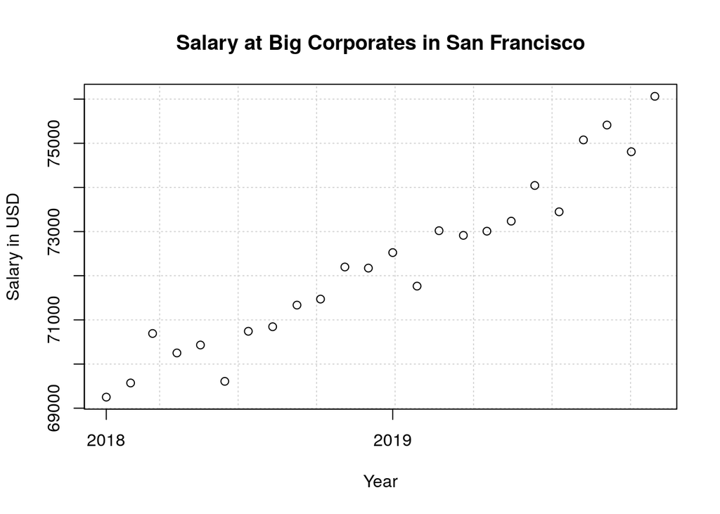

```r
plot(x = SF_5000more$Date, y = SF_5000more$Salary,
     main = "Salary at Big Corporates in San Francisco",
     xlab = "Year",
     ylab = "Salary in USD",
     panel.first = grid())
```

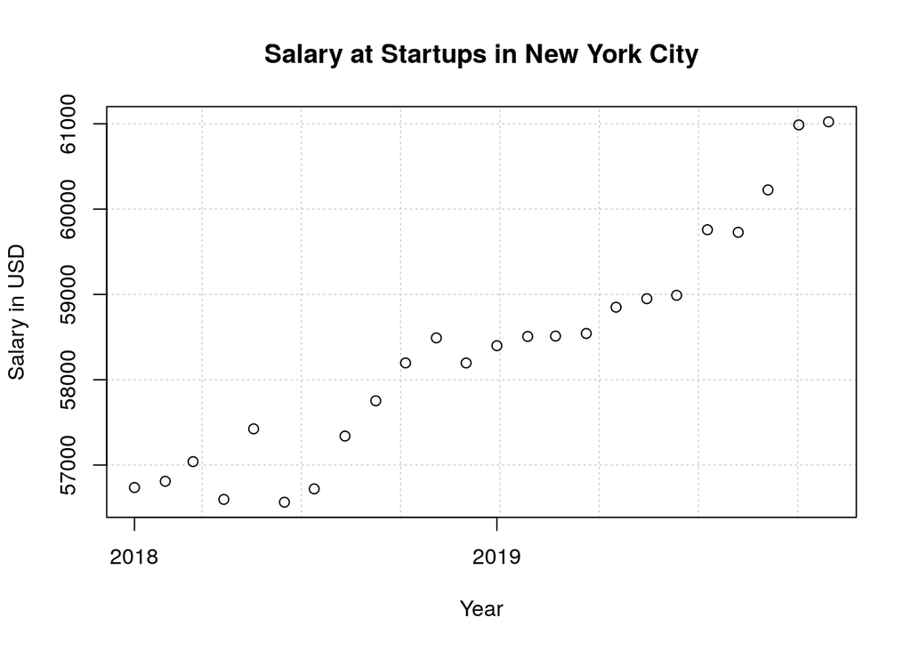

```r
NYC_startup_agg <- aggregate(formula = Salary ~ Date, data = NYC_startup, FUN = mean)

plot(x = NYC_startup_agg$Date, y = NYC_startup_agg$Salary,
     type = "p",
     main = "Salary at Startups in New York City",
     xlab = "Year",
     ylab = "Salary in USD",
     panel.first = grid())
```

By looking at two figures above, it is proven that for 2018 and 2019, big companies in San Francisco always pay their employees higher than startups in New York City pay. Therefore, there is an advice for this case:

```
If you were to work in the US and choose either to work in San Francisco or New York City, it is recommended to apply for a job at a big company. It produces more money for you!
```

## 6.4 What is the relationship between salary and job openings in the US?

In order to answer this question, we need `TimeSeries_Salary` and `TimeSeries_JobOpenings` dataframes. Afterwards, we group them in their months and years, make an average of salary and job openings for each group, and then sort them by month and year. After we’ve got the new dataframes, we can plot them and calculate the correlation.

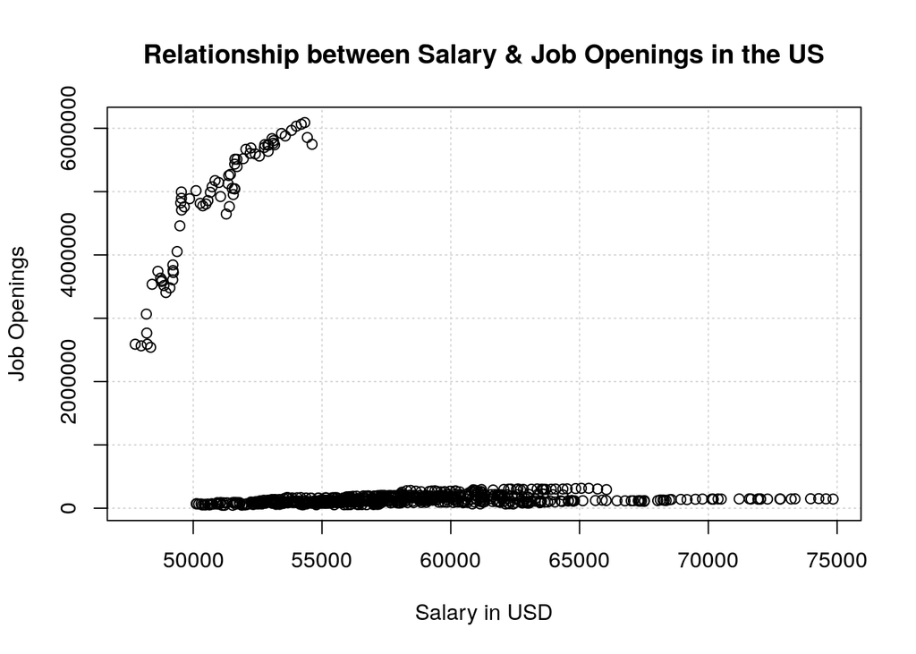

```r
SA <- TimeSeries_Salary %>%
  mutate(Month = month(Date, label = T), Year = year(Date)) %>%
  group_by(Metro, Month, Year) %>%
  summarise(Mean_Salary = mean(Salary)) %>%
  ungroup() %>%
  arrange(Year)

JO <- TimeSeries_JobOpenings %>%
  mutate(Month = month(Date, label = T), Year = year(Date)) %>%
  group_by(Metro, Month, Year) %>%
  summarise(Mean_JobOpenings = mean(Job_Openings)) %>%
  ungroup() %>%
  arrange(Year)

options(scipen = 999)
plot(x = SA$Mean_Salary, y = JO$Mean_JobOpenings,
     main = "Relationship between Salary & Job Openings in the US",
     xlab = "Salary in USD",
     ylab = "Job Openings",
     panel.first = grid())
```

```r
cor_SA_JO <- round(cor(SA$Mean_Salary, JO$Mean_JobOpenings), 3)
paste0("The corelation value between Salary & Job Openings in the US: ", cor_SA_JO)
```

```
## [1] "The corelation value between Salary & Job Openings in the US: -0.363"
```

As seen in the figure above, almost there is a little relationship between salary and job openings. We could say that in majority, small number (less than 1 million) of job openings spreads somewhat evenly on the salary. High density of the figure can be seen between ranges x: 50K-65K and y:0-1M. Meanwhile, there are some outliers in which small number of salaries is open in a large number of job openings.

In addition to analyze the relationship by viewing on the figure, we can use correlation formula to examine both salary and job openings. We also can see below the figure above that the correlation value of such relationship is `-0.363`. This means that both have a small negative relationship which means when the salary goes up, the job openings somewhat goes down, and vice versa.

# 7 Conclusions

We’ve finished all stages to deliver this article. And now, let’s conclude all of them:

- We’ve explained many things about the data used in Dataset section.
- We’ve prepared the data, i.e. scraping the Glassdoor website, downloading the files, importing the files to RStudio, and preparing a single dataframe, in Preparation.
- We’ve performed Data Cleansing to clean the data.
- We’ve transformed the data in Data Transformation so that it can be easily used in the next sections.
- We’ve analyzed the data in Analysis to answer the research questions.
  1. Mostly the highest paid jobs are dominated by Attorney and Pharmacist.
  2. Energy & Utilities, Biotech & Pharmaceuticals, Aerospace & Defense, Computer Software & Hardware, Consulting, and Architecture & Civil Engineering are top 5 sectors with the highest salary in Boston.
  3. It is true that big corporates in San Francisco pay more for their employees than startups in New York City pay; even the gap is steep enough.
  4. The relationship between salary and job openings is small negative with correlation value `-0.363`.
- We’ve answered all questions.